# Chap5. Excercise

#### 5.2.4 Exercise

##### Prom 1. Find all flights that

1. Had an arrival delay of two or more hours.

```r
arrdelay_more2h <- flights %>%
  filter(arr_delay >= 120)
head(arrdelay_more2h)
```

| year | month | day | dep_time | sched_dep_time | dep_delay | arr_time | sched_arr_time | arr_delay | carrier | flight | tailnum | origin | dest | air_time | distance | hour | minute | time_hour |
| --- | --- | --- | --- | --- | --- | --- | --- | --- | --- | --- | --- | --- | --- | --- | --- | --- | --- | --- |
| 2013 | 1 | 1 | 811 | 630 | 101 | 1047 | 830 | 137 | MQ | 4576 | N531MQ | LGA | CLT | 118 | 544 | 6 | 30 | 2013-01-01 06:00:00 |
| 2013 | 1 | 1 | 848 | 1835 | 853 | 1001 | 1950 | 851 | MQ | 3944 | N942MQ | JFK | BWI | 41 | 184 | 18 | 35 | 2013-01-01 18:00:00 |
| 2013 | 1 | 1 | 957 | 733 | 144 | 1056 | 853 | 123 | UA | 856 | N534UA | EWR | BOS | 37 | 200 | 7 | 33 | 2013-01-01 07:00:00 |
| 2013 | 1 | 1 | 1114 | 900 | 134 | 1447 | 1222 | 145 | UA | 1086 | N76502 | LGA | IAH | 248 | 1416 | 9 | 0 | 2013-01-01 09:00:00 |
| 2013 | 1 | 1 | 1505 | 1310 | 115 | 1638 | 1431 | 127 | EV | 4497 | N17984 | EWR | RIC | 63 | 277 | 13 | 10 | 2013-01-01 13:00:00 |
| 2013 | 1 | 1 | 1525 | 1340 | 105 | 1831 | 1626 | 125 | B6 | 525 | N231JB | EWR | MCO | 152 | 937 | 13 | 40 | 2013-01-01 13:00:00 |

2. Flew to Houston (IAH or HOU)

```r
Flew_to_Hou <- flights %>%
  filter(dest == "IAH"| dest == "HOU")
head(Flew_to_Hou)
```

| year | month | day | dep_time | sched_dep_time | dep_delay | arr_time | sched_arr_time | arr_delay | carrier | flight | tailnum | origin | dest | air_time | distance | hour | minute | time_hour |
| --- | --- | --- | --- | --- | --- | --- | --- | --- | --- | --- | --- | --- | --- | --- | --- | --- | --- | --- |
| 2013 | 1 | 1 | 517 | 515 | 2 | 830 | 819 | 11 | UA | 1545 | N14228 | EWR | IAH | 227 | 1400 | 5 | 15 | 2013-01-01 05:00:00 |
| 2013 | 1 | 1 | 533 | 529 | 4 | 850 | 830 | 20 | UA | 1714 | N24211 | LGA | IAH | 227 | 1416 | 5 | 29 | 2013-01-01 05:00:00 |
| 2013 | 1 | 1 | 623 | 627 | -4 | 933 | 932 | 1 | UA | 496 | N459UA | LGA | IAH | 229 | 1416 | 6 | 27 | 2013-01-01 06:00:00 |
| 2013 | 1 | 1 | 728 | 732 | -4 | 1041 | 1038 | 3 | UA | 473 | N488UA | LGA | IAH | 238 | 1416 | 7 | 32 | 2013-01-01 07:00:00 |
| 2013 | 1 | 1 | 739 | 739 | 0 | 1104 | 1038 | 26 | UA | 1479 | N37408 | EWR | IAH | 249 | 1400 | 7 | 39 | 2013-01-01 07:00:00 |
| 2013 | 1 | 1 | 908 | 908 | 0 | 1228 | 1219 | 9 | UA | 1220 | N12216 | EWR | IAH | 233 | 1400 | 9 | 8 | 2013-01-01 09:00:00 |

3. Were operated by United, American, or Delta
- 각 항공사별 abbreviation은`https://www.transtats.bts.gov/DL_SelectFields.asp?Table_ID=236`를 참조했다.`

```r
Operby_UAAADL <- flights %>%
  filter(carrier == "UA"|carrier == "AA"|carrier == "DL")
head(Operby_UAAADL)
```

| year | month | day | dep_time | sched_dep_time | dep_delay | arr_time | sched_arr_time | arr_delay | carrier | flight | tailnum | origin | dest | air_time | distance | hour | minute | time_hour |
| --- | --- | --- | --- | --- | --- | --- | --- | --- | --- | --- | --- | --- | --- | --- | --- | --- | --- | --- |
| 2013 | 1 | 1 | 517 | 515 | 2 | 830 | 819 | 11 | UA | 1545 | N14228 | EWR | IAH | 227 | 1400 | 5 | 15 | 2013-01-01 05:00:00 |
| 2013 | 1 | 1 | 533 | 529 | 4 | 850 | 830 | 20 | UA | 1714 | N24211 | LGA | IAH | 227 | 1416 | 5 | 29 | 2013-01-01 05:00:00 |
| 2013 | 1 | 1 | 542 | 540 | 2 | 923 | 850 | 33 | AA | 1141 | N619AA | JFK | MIA | 160 | 1089 | 5 | 40 | 2013-01-01 05:00:00 |
| 2013 | 1 | 1 | 554 | 600 | -6 | 812 | 837 | -25 | DL | 461 | N668DN | LGA | ATL | 116 | 762 | 6 | 0 | 2013-01-01 06:00:00 |
| 2013 | 1 | 1 | 554 | 558 | -4 | 740 | 728 | 12 | UA | 1696 | N39463 | EWR | ORD | 150 | 719 | 5 | 58 | 2013-01-01 05:00:00 |
| 2013 | 1 | 1 | 558 | 600 | -2 | 753 | 745 | 8 | AA | 301 | N3ALAA | LGA | ORD | 138 | 733 | 6 | 0 | 2013-01-01 06:00:00 |

4. Departed in summer (July, August, and September)

```r
Dep_summer <- flights %>%
  filter(month == 7| month == 8| month == 9)
head(Dep_summer)
```

| year | month | day | dep_time | sched_dep_time | dep_delay | arr_time | sched_arr_time | arr_delay | carrier | flight | tailnum | origin | dest | air_time | distance | hour | minute | time_hour |
| --- | --- | --- | --- | --- | --- | --- | --- | --- | --- | --- | --- | --- | --- | --- | --- | --- | --- | --- |
| 2013 | 7 | 1 | 1 | 2029 | 212 | 236 | 2359 | 157 | B6 | 915 | N653JB | JFK | SFO | 315 | 2586 | 20 | 29 | 2013-07-01 20:00:00 |
| 2013 | 7 | 1 | 2 | 2359 | 3 | 344 | 344 | 0 | B6 | 1503 | N805JB | JFK | SJU | 200 | 1598 | 23 | 59 | 2013-07-01 23:00:00 |
| 2013 | 7 | 1 | 29 | 2245 | 104 | 151 | 1 | 110 | B6 | 234 | N348JB | JFK | BTV | 66 | 266 | 22 | 45 | 2013-07-01 22:00:00 |
| 2013 | 7 | 1 | 43 | 2130 | 193 | 322 | 14 | 188 | B6 | 1371 | N794JB | LGA | FLL | 143 | 1076 | 21 | 30 | 2013-07-01 21:00:00 |
| 2013 | 7 | 1 | 44 | 2150 | 174 | 300 | 100 | 120 | AA | 185 | N324AA | JFK | LAX | 297 | 2475 | 21 | 50 | 2013-07-01 21:00:00 |
| 2013 | 7 | 1 | 46 | 2051 | 235 | 304 | 2358 | 186 | B6 | 165 | N640JB | JFK | PDX | 304 | 2454 | 20 | 51 | 2013-07-01 20:00:00 |

5. Arrived more than two hours late, but didn’t leave late

```r
Slow_air <- flights %>%
  filter(arr_delay > 120, !(dep_delay > 0))
head(Slow_air)
```

| year | month | day | dep_time | sched_dep_time | dep_delay | arr_time | sched_arr_time | arr_delay | carrier | flight | tailnum | origin | dest | air_time | distance | hour | minute | time_hour |
| --- | --- | --- | --- | --- | --- | --- | --- | --- | --- | --- | --- | --- | --- | --- | --- | --- | --- | --- |
| 2013 | 1 | 27 | 1419 | 1420 | -1 | 1754 | 1550 | 124 | MQ | 3728 | N1EAMQ | EWR | ORD | 135 | 719 | 14 | 20 | 2013-01-27 14:00:00 |
| 2013 | 10 | 7 | 1350 | 1350 | 0 | 1736 | 1526 | 130 | EV | 5181 | N611QX | LGA | MSN | 117 | 812 | 13 | 50 | 2013-10-07 13:00:00 |
| 2013 | 10 | 7 | 1357 | 1359 | -2 | 1858 | 1654 | 124 | AA | 1151 | N3CMAA | LGA | DFW | 192 | 1389 | 13 | 59 | 2013-10-07 13:00:00 |
| 2013 | 10 | 16 | 657 | 700 | -3 | 1258 | 1056 | 122 | B6 | 3 | N703JB | JFK | SJU | 225 | 1598 | 7 | 0 | 2013-10-16 07:00:00 |
| 2013 | 11 | 1 | 658 | 700 | -2 | 1329 | 1015 | 194 | VX | 399 | N629VA | JFK | LAX | 336 | 2475 | 7 | 0 | 2013-11-01 07:00:00 |
| 2013 | 3 | 18 | 1844 | 1847 | -3 | 39 | 2219 | 140 | UA | 389 | N560UA | JFK | SFO | 386 | 2586 | 18 | 47 | 2013-03-18 18:00:00 |

6. Were delayed by at least an hour, but made up over 30 minutes in flight.

```r
Did_best <- flights %>%
  filter(dep_delay >=60, dep_time <= 30)
head(Did_best)
```

| year | month | day | dep_time | sched_dep_time | dep_delay | arr_time | sched_arr_time | arr_delay | carrier | flight | tailnum | origin | dest | air_time | distance | hour | minute | time_hour |
| --- | --- | --- | --- | --- | --- | --- | --- | --- | --- | --- | --- | --- | --- | --- | --- | --- | --- | --- |
| 2013 | 1 | 13 | 1 | 2249 | 72 | 108 | 2357 | 71 | B6 | 22 | N206JB | JFK | SYR | 41 | 209 | 22 | 49 | 2013-01-13 22:00:00 |
| 2013 | 1 | 13 | 3 | 2030 | 213 | 340 | 2350 | 230 | B6 | 1069 | N281JB | JFK | AUS | 243 | 1521 | 20 | 30 | 2013-01-13 20:00:00 |
| 2013 | 1 | 13 | 10 | 2135 | 155 | 305 | 36 | 149 | B6 | 11 | N595JB | JFK | FLL | 144 | 1069 | 21 | 35 | 2013-01-13 21:00:00 |
| 2013 | 1 | 16 | 2 | 2125 | 157 | 119 | 2250 | 149 | MQ | 4660 | N504MQ | LGA | BNA | 121 | 764 | 21 | 25 | 2013-01-16 21:00:00 |
| 2013 | 1 | 16 | 3 | 1946 | 257 | 212 | 2154 | 258 | EV | 4536 | N16987 | EWR | CVG | 111 | 569 | 19 | 46 | 2013-01-16 19:00:00 |
| 2013 | 1 | 25 | 15 | 1815 | 360 | 208 | 1958 | 370 | 9E | 4019 | N8646A | JFK | RIC | 56 | 288 | 18 | 15 | 2013-01-25 18:00:00 |

7. Departed between midnight and 6am (inclusive)

```r
Dep_at_night <- flights %>%
  filter(dep_time >=0, dep_time <= 600)
head(Dep_at_night)
```

| year | month | day | dep_time | sched_dep_time | dep_delay | arr_time | sched_arr_time | arr_delay | carrier | flight | tailnum | origin | dest | air_time | distance | hour | minute | time_hour |
| --- | --- | --- | --- | --- | --- | --- | --- | --- | --- | --- | --- | --- | --- | --- | --- | --- | --- | --- |
| 2013 | 1 | 1 | 517 | 515 | 2 | 830 | 819 | 11 | UA | 1545 | N14228 | EWR | IAH | 227 | 1400 | 5 | 15 | 2013-01-01 05:00:00 |
| 2013 | 1 | 1 | 533 | 529 | 4 | 850 | 830 | 20 | UA | 1714 | N24211 | LGA | IAH | 227 | 1416 | 5 | 29 | 2013-01-01 05:00:00 |
| 2013 | 1 | 1 | 542 | 540 | 2 | 923 | 850 | 33 | AA | 1141 | N619AA | JFK | MIA | 160 | 1089 | 5 | 40 | 2013-01-01 05:00:00 |
| 2013 | 1 | 1 | 544 | 545 | -1 | 1004 | 1022 | -18 | B6 | 725 | N804JB | JFK | BQN | 183 | 1576 | 5 | 45 | 2013-01-01 05:00:00 |
| 2013 | 1 | 1 | 554 | 600 | -6 | 812 | 837 | -25 | DL | 461 | N668DN | LGA | ATL | 116 | 762 | 6 | 0 | 2013-01-01 06:00:00 |
| 2013 | 1 | 1 | 554 | 558 | -4 | 740 | 728 | 12 | UA | 1696 | N39463 | EWR | ORD | 150 | 719 | 5 | 58 | 2013-01-01 05:00:00 |

##### Prom2. Another useful dplyr filtering helper is between(). What does it do? Can you use it to simplify the code needed to answer the previous challenges?

```r
?between
between(1, 2, 3)
```

```
[1] FALSE
```

```r
between(2.5, 2, 3)
```

```
[1] TRUE
```

```r
between(2, 2, 3)
```

```
[1] TRUE
```

- 좌, 우의 boundary 값이 주어졌을때, 첫번째 인수의 값이 좌 우의 boundary안에 포함되는지를 판단한다. 실험결과 경계값은 TRUE로 판단한다.
- Prom1의 4번 문제를 간단하게 만들 수 있다.(혹은 7번도) 4번 코드를 다시 짜면

```r
Dep_summer2 <- flights %>%
  filter(between(month, 7,9))
head(Dep_summer2)
```

| year | month | day | dep_time | sched_dep_time | dep_delay | arr_time | sched_arr_time | arr_delay | carrier | flight | tailnum | origin | dest | air_time | distance | hour | minute | time_hour |
| --- | --- | --- | --- | --- | --- | --- | --- | --- | --- | --- | --- | --- | --- | --- | --- | --- | --- | --- |
| 2013 | 7 | 1 | 1 | 2029 | 212 | 236 | 2359 | 157 | B6 | 915 | N653JB | JFK | SFO | 315 | 2586 | 20 | 29 | 2013-07-01 20:00:00 |
| 2013 | 7 | 1 | 2 | 2359 | 3 | 344 | 344 | 0 | B6 | 1503 | N805JB | JFK | SJU | 200 | 1598 | 23 | 59 | 2013-07-01 23:00:00 |
| 2013 | 7 | 1 | 29 | 2245 | 104 | 151 | 1 | 110 | B6 | 234 | N348JB | JFK | BTV | 66 | 266 | 22 | 45 | 2013-07-01 22:00:00 |
| 2013 | 7 | 1 | 43 | 2130 | 193 | 322 | 14 | 188 | B6 | 1371 | N794JB | LGA | FLL | 143 | 1076 | 21 | 30 | 2013-07-01 21:00:00 |
| 2013 | 7 | 1 | 44 | 2150 | 174 | 300 | 100 | 120 | AA | 185 | N324AA | JFK | LAX | 297 | 2475 | 21 | 50 | 2013-07-01 21:00:00 |
| 2013 | 7 | 1 | 46 | 2051 | 235 | 304 | 2358 | 186 | B6 | 165 | N640JB | JFK | PDX | 304 | 2454 | 20 | 51 | 2013-07-01 20:00:00 |

##### Prom 3. How many flights have a missing dep_time? What other variables are missing? What might these rows represent?

```r
Miss_deptime <- flights %>%
  filter(is.na(dep_time))
head(Miss_deptime)
```

| year | month | day | dep_time | sched_dep_time | dep_delay | arr_time | sched_arr_time | arr_delay | carrier | flight | tailnum | origin | dest | air_time | distance | hour | minute | time_hour |
| --- | --- | --- | --- | --- | --- | --- | --- | --- | --- | --- | --- | --- | --- | --- | --- | --- | --- | --- |
| 2013 | 1 | 1 | NA | 1630 | NA | NA | 1815 | NA | EV | 4308 | N18120 | EWR | RDU | NA | 416 | 16 | 30 | 2013-01-01 16:00:00 |
| 2013 | 1 | 1 | NA | 1935 | NA | NA | 2240 | NA | AA | 791 | N3EHAA | LGA | DFW | NA | 1389 | 19 | 35 | 2013-01-01 19:00:00 |
| 2013 | 1 | 1 | NA | 1500 | NA | NA | 1825 | NA | AA | 1925 | N3EVAA | LGA | MIA | NA | 1096 | 15 | 0 | 2013-01-01 15:00:00 |
| 2013 | 1 | 1 | NA | 600 | NA | NA | 901 | NA | B6 | 125 | N618JB | JFK | FLL | NA | 1069 | 6 | 0 | 2013-01-01 06:00:00 |
| 2013 | 1 | 2 | NA | 1540 | NA | NA | 1747 | NA | EV | 4352 | N10575 | EWR | CVG | NA | 569 | 15 | 40 | 2013-01-02 15:00:00 |
| 2013 | 1 | 2 | NA | 1620 | NA | NA | 1746 | NA | EV | 4406 | N13949 | EWR | PIT | NA | 319 | 16 | 20 | 2013-01-02 16:00:00 |

- 위의 결과가 출발 시간이 없어진 것들인데, 출발 지연시간, 도착 시간, 도착 지연시간, 운항 시간이 모두 NA 값인 것을 확인할 수 있다. 이러한 비행기들은 계획은 되었으나 출발하지 못한 항공편, 즉 결항된 비행기인 것을 알 수 있다.

##### Prom 4. Why is NA ^ 0 not missing? Why is NA | TRUE not missing? Why is FALSE & NA not missing? Can you figure out the general rule? (NA * 0 is a tricky counterexample!)

```r
NA ^ 0
```

```
[1] 1
```

```r
NA | TRUE
```

```
[1] TRUE
```

```r
FALSE & NA
```

```
[1] FALSE
```

```r
NA * 0
```

```
[1] NA
```

- __“`NA`에 관계없이 일정한 답이 나오는 경우”__에 한해서 `NA`가 포함된 식도 답이 나오는 것으로 추측한다. 가령 `NA^0`의 경우 NA가 어떤 실수든 간에 1으로 답이 정해져 있다. `NA|TRUE`역시 이미 하나의 `TRUE`가 있기 때문에 다른 식의 결과가 무엇이든 간에 `TRUE` 값을 가지게 되어 있다. 이는 `FALSE & NA`의 경우와도 마찬가지 인데, 이미 한쪽이 `FALSE`이기 때문에 나머지 하나의 식이 무엇이든 간에 `FALSE`가 되기 때문이다.
- `NA * 0` 의 경우 다소 직관과 어긋나지만, 수학적으로 __무한대 * 0__의 값은 부정(정해지지 않음) 이라는 것을 생각해보면 `NA`의 값을 가지는 것이 이해가 될 수 도 있다. 가령 다음과 같은 코드를 고려해 보면

```r
(1/0) * 0
```

```
[1] NaN
```

- 답이 정해지지 않았다는 결과를 도출할 수 있다. 다만 수학적으로 식의 답을 알 수 없는 경우도 R에서 답이 나오는 경우가 있는데,

```r
(1/0)^0
```

```
[1] 1
```

```r
(1/0)^0 * (0^0)
```

```
[1] 1
```

- 를 고려해보면 우리의 수학적 직관과는 다소 다른 결과를 보임은 알 수 있다. 그렇지만 어쨌거나 결과가 고정된다는 점에서 `NA ^ 0`의 결과가 나온다는 것은 이상하지 않다.

#### 5.3.1. Exercise

##### Prom1. How could you use arrange() to sort all missing values to the start? (Hint: use is.na()).

```r
reverseNA <- flights %>%
  arrange(desc(is.na(dep_time)))
head(reverseNA)
```

| year | month | day | dep_time | sched_dep_time | dep_delay | arr_time | sched_arr_time | arr_delay | carrier | flight | tailnum | origin | dest | air_time | distance | hour | minute | time_hour |
| --- | --- | --- | --- | --- | --- | --- | --- | --- | --- | --- | --- | --- | --- | --- | --- | --- | --- | --- |
| 2013 | 1 | 1 | NA | 1630 | NA | NA | 1815 | NA | EV | 4308 | N18120 | EWR | RDU | NA | 416 | 16 | 30 | 2013-01-01 16:00:00 |
| 2013 | 1 | 1 | NA | 1935 | NA | NA | 2240 | NA | AA | 791 | N3EHAA | LGA | DFW | NA | 1389 | 19 | 35 | 2013-01-01 19:00:00 |
| 2013 | 1 | 1 | NA | 1500 | NA | NA | 1825 | NA | AA | 1925 | N3EVAA | LGA | MIA | NA | 1096 | 15 | 0 | 2013-01-01 15:00:00 |
| 2013 | 1 | 1 | NA | 600 | NA | NA | 901 | NA | B6 | 125 | N618JB | JFK | FLL | NA | 1069 | 6 | 0 | 2013-01-01 06:00:00 |
| 2013 | 1 | 2 | NA | 1540 | NA | NA | 1747 | NA | EV | 4352 | N10575 | EWR | CVG | NA | 569 | 15 | 40 | 2013-01-02 15:00:00 |
| 2013 | 1 | 2 | NA | 1620 | NA | NA | 1746 | NA | EV | 4406 | N13949 | EWR | PIT | NA | 319 | 16 | 20 | 2013-01-02 16:00:00 |

- `is.na()`를 사용하게 되면 NA 값들이 1로 바뀌게 되고 이를 내림차순으로 정렬하게 되면 `NA`값들을 가진 행들이 위로 올라오게 됨을 알 수 있다.

##### Prom2. Sort flights to find the most delayed flights. Find the flights that left earliest.

```r
arrange_delay <- flights %>%
  arrange(desc(dep_delay))
head(arrange_delay)
```

| year | month | day | dep_time | sched_dep_time | dep_delay | arr_time | sched_arr_time | arr_delay | carrier | flight | tailnum | origin | dest | air_time | distance | hour | minute | time_hour |
| --- | --- | --- | --- | --- | --- | --- | --- | --- | --- | --- | --- | --- | --- | --- | --- | --- | --- | --- |
| 2013 | 1 | 9 | 641 | 900 | 1301 | 1242 | 1530 | 1272 | HA | 51 | N384HA | JFK | HNL | 640 | 4983 | 9 | 0 | 2013-01-09 09:00:00 |
| 2013 | 6 | 15 | 1432 | 1935 | 1137 | 1607 | 2120 | 1127 | MQ | 3535 | N504MQ | JFK | CMH | 74 | 483 | 19 | 35 | 2013-06-15 19:00:00 |
| 2013 | 1 | 10 | 1121 | 1635 | 1126 | 1239 | 1810 | 1109 | MQ | 3695 | N517MQ | EWR | ORD | 111 | 719 | 16 | 35 | 2013-01-10 16:00:00 |
| 2013 | 9 | 20 | 1139 | 1845 | 1014 | 1457 | 2210 | 1007 | AA | 177 | N338AA | JFK | SFO | 354 | 2586 | 18 | 45 | 2013-09-20 18:00:00 |
| 2013 | 7 | 22 | 845 | 1600 | 1005 | 1044 | 1815 | 989 | MQ | 3075 | N665MQ | JFK | CVG | 96 | 589 | 16 | 0 | 2013-07-22 16:00:00 |
| 2013 | 4 | 10 | 1100 | 1900 | 960 | 1342 | 2211 | 931 | DL | 2391 | N959DL | JFK | TPA | 139 | 1005 | 19 | 0 | 2013-04-10 19:00:00 |

```r
leave_early <- flights %>%
  filter(dep_time < 100) %>%
  arrange(dep_time)
head(leave_early)
```

| year | month | day | dep_time | sched_dep_time | dep_delay | arr_time | sched_arr_time | arr_delay | carrier | flight | tailnum | origin | dest | air_time | distance | hour | minute | time_hour |
| --- | --- | --- | --- | --- | --- | --- | --- | --- | --- | --- | --- | --- | --- | --- | --- | --- | --- | --- |
| 2013 | 1 | 13 | 1 | 2249 | 72 | 108 | 2357 | 71 | B6 | 22 | N206JB | JFK | SYR | 41 | 209 | 22 | 49 | 2013-01-13 22:00:00 |
| 2013 | 1 | 31 | 1 | 2100 | 181 | 124 | 2225 | 179 | WN | 530 | N550WN | LGA | MDW | 127 | 725 | 21 | 0 | 2013-01-31 21:00:00 |
| 2013 | 11 | 13 | 1 | 2359 | 2 | 442 | 440 | 2 | B6 | 1503 | N627JB | JFK | SJU | 194 | 1598 | 23 | 59 | 2013-11-13 23:00:00 |
| 2013 | 12 | 16 | 1 | 2359 | 2 | 447 | 437 | 10 | B6 | 839 | N607JB | JFK | BQN | 202 | 1576 | 23 | 59 | 2013-12-16 23:00:00 |
| 2013 | 12 | 20 | 1 | 2359 | 2 | 430 | 440 | -10 | B6 | 1503 | N608JB | JFK | SJU | 182 | 1598 | 23 | 59 | 2013-12-20 23:00:00 |
| 2013 | 12 | 26 | 1 | 2359 | 2 | 437 | 440 | -3 | B6 | 1503 | N527JB | JFK | SJU | 197 | 1598 | 23 | 59 | 2013-12-26 23:00:00 |

##### Prom3.Sort flights to find the fastest flights.

- 속도는 거리/시간임을 기억하자.

```r
fast_flights <- flights %>%
  arrange(desc(distance/air_time))
fast_flights
```

| year | month | day | dep_time | sched_dep_time | dep_delay | arr_time | sched_arr_time | arr_delay | carrier | flight | tailnum | origin | dest | air_time | distance | hour | minute | time_hour |
| --- | --- | --- | --- | --- | --- | --- | --- | --- | --- | --- | --- | --- | --- | --- | --- | --- | --- | --- |
| 2013 | 5 | 25 | 1709 | 1700 | 9 | 1923 | 1937 | -14 | DL | 1499 | N666DN | LGA | ATL | 65 | 762 | 17 | 0 | 2013-05-25 17:00:00 |
| 2013 | 7 | 2 | 1558 | 1513 | 45 | 1745 | 1719 | 26 | EV | 4667 | N17196 | EWR | MSP | 93 | 1008 | 15 | 13 | 2013-07-02 15:00:00 |
| 2013 | 5 | 13 | 2040 | 2025 | 15 | 2225 | 2226 | -1 | EV | 4292 | N14568 | EWR | GSP | 55 | 594 | 20 | 25 | 2013-05-13 20:00:00 |
| 2013 | 3 | 23 | 1914 | 1910 | 4 | 2045 | 2043 | 2 | EV | 3805 | N12567 | EWR | BNA | 70 | 748 | 19 | 10 | 2013-03-23 19:00:00 |
| 2013 | 1 | 12 | 1559 | 1600 | -1 | 1849 | 1917 | -28 | DL | 1902 | N956DL | LGA | PBI | 105 | 1035 | 16 | 0 | 2013-01-12 16:00:00 |
| 2013 | 11 | 17 | 650 | 655 | -5 | 1059 | 1150 | -51 | DL | 315 | N3768 | JFK | SJU | 170 | 1598 | 6 | 55 | 2013-11-17 06:00:00 |
| 2013 | 2 | 21 | 2355 | 2358 | -3 | 412 | 438 | -26 | B6 | 707 | N779JB | JFK | SJU | 172 | 1598 | 23 | 58 | 2013-02-21 23:00:00 |
| 2013 | 11 | 17 | 759 | 800 | -1 | 1212 | 1255 | -43 | AA | 936 | N5FFAA | JFK | STT | 175 | 1623 | 8 | 0 | 2013-11-17 08:00:00 |
| 2013 | 11 | 16 | 2003 | 1925 | 38 | 17 | 36 | -19 | DL | 347 | N3773D | JFK | SJU | 173 | 1598 | 19 | 25 | 2013-11-16 19:00:00 |
| 2013 | 11 | 16 | 2349 | 2359 | -10 | 402 | 440 | -38 | B6 | 1503 | N571JB | JFK | SJU | 173 | 1598 | 23 | 59 | 2013-11-16 23:00:00 |

[output cut: 990 more lines]

- 결과에 따르면 2013년 5월 25일 출발한 ATL(아틀란타로 추정)행 비행기 DL1499편이다.
- 속도까지 나오기를 원한다면

```r
velo_fligths <- flights %>%
  mutate(velocity = distance/air_time) %>%
  select(velocity,carrier,flight, tailnum, everything()) %>%
  arrange(desc(velocity))
head(velo_fligths)
```

| velocity | carrier | flight | tailnum | year | month | day | dep_time | sched_dep_time | dep_delay | arr_time | sched_arr_time | arr_delay | origin | dest | air_time | distance | hour | minute | time_hour |
| --- | --- | --- | --- | --- | --- | --- | --- | --- | --- | --- | --- | --- | --- | --- | --- | --- | --- | --- | --- |
| 11.723077 | DL | 1499 | N666DN | 2013 | 5 | 25 | 1709 | 1700 | 9 | 1923 | 1937 | -14 | LGA | ATL | 65 | 762 | 17 | 0 | 2013-05-25 17:00:00 |
| 10.838710 | EV | 4667 | N17196 | 2013 | 7 | 2 | 1558 | 1513 | 45 | 1745 | 1719 | 26 | EWR | MSP | 93 | 1008 | 15 | 13 | 2013-07-02 15:00:00 |
| 10.800000 | EV | 4292 | N14568 | 2013 | 5 | 13 | 2040 | 2025 | 15 | 2225 | 2226 | -1 | EWR | GSP | 55 | 594 | 20 | 25 | 2013-05-13 20:00:00 |
| 10.685714 | EV | 3805 | N12567 | 2013 | 3 | 23 | 1914 | 1910 | 4 | 2045 | 2043 | 2 | EWR | BNA | 70 | 748 | 19 | 10 | 2013-03-23 19:00:00 |
| 9.857143 | DL | 1902 | N956DL | 2013 | 1 | 12 | 1559 | 1600 | -1 | 1849 | 1917 | -28 | LGA | PBI | 105 | 1035 | 16 | 0 | 2013-01-12 16:00:00 |
| 9.400000 | DL | 315 | N3768 | 2013 | 11 | 17 | 650 | 655 | -5 | 1059 | 1150 | -51 | JFK | SJU | 170 | 1598 | 6 | 55 | 2013-11-17 06:00:00 |

##### Prom4. Which flights travelled the longest? Which travelled the shortest?

```r
trav_long <- flights %>%
  filter(is.na(dep_time) == FALSE) %>%
  arrange(distance) %>%
  select(distance, carrier, flight,dest,everything())
head(trav_long)
```

| distance | carrier | flight | dest | year | month | day | dep_time | sched_dep_time | dep_delay | arr_time | sched_arr_time | arr_delay | tailnum | origin | air_time | hour | minute | time_hour |
| --- | --- | --- | --- | --- | --- | --- | --- | --- | --- | --- | --- | --- | --- | --- | --- | --- | --- | --- |
| 80 | EV | 3833 | PHL | 2013 | 1 | 3 | 2127 | 2129 | -2 | 2222 | 2224 | -2 | N13989 | EWR | 30 | 21 | 29 | 2013-01-03 21:00:00 |
| 80 | EV | 4193 | PHL | 2013 | 1 | 4 | 1240 | 1200 | 40 | 1333 | 1306 | 27 | N14972 | EWR | 30 | 12 | 0 | 2013-01-04 12:00:00 |
| 80 | EV | 4502 | PHL | 2013 | 1 | 4 | 1829 | 1615 | 134 | 1937 | 1721 | 136 | N15983 | EWR | 28 | 16 | 15 | 2013-01-04 16:00:00 |
| 80 | EV | 4645 | PHL | 2013 | 1 | 4 | 2128 | 2129 | -1 | 2218 | 2224 | -6 | N27962 | EWR | 32 | 21 | 29 | 2013-01-04 21:00:00 |
| 80 | EV | 4193 | PHL | 2013 | 1 | 5 | 1155 | 1200 | -5 | 1241 | 1306 | -25 | N14902 | EWR | 29 | 12 | 0 | 2013-01-05 12:00:00 |
| 80 | EV | 4619 | PHL | 2013 | 1 | 6 | 2125 | 2129 | -4 | 2224 | 2224 | 0 | N22909 | EWR | 22 | 21 | 29 | 2013-01-06 21:00:00 |

```r
tail(trav_long)
```

| distance | carrier | flight | dest | year | month | day | dep_time | sched_dep_time | dep_delay | arr_time | sched_arr_time | arr_delay | tailnum | origin | air_time | hour | minute | time_hour |
| --- | --- | --- | --- | --- | --- | --- | --- | --- | --- | --- | --- | --- | --- | --- | --- | --- | --- | --- |
| 4983 | HA | 51 | HNL | 2013 | 9 | 23 | 955 | 1000 | -5 | 1437 | 1445 | -8 | N388HA | JFK | 616 | 10 | 0 | 2013-09-23 10:00:00 |
| 4983 | HA | 51 | HNL | 2013 | 9 | 25 | 1001 | 1000 | 1 | 1508 | 1445 | 23 | N389HA | JFK | 636 | 10 | 0 | 2013-09-25 10:00:00 |
| 4983 | HA | 51 | HNL | 2013 | 9 | 27 | 951 | 1000 | -9 | 1442 | 1445 | -3 | N390HA | JFK | 629 | 10 | 0 | 2013-09-27 10:00:00 |
| 4983 | HA | 51 | HNL | 2013 | 9 | 28 | 955 | 1000 | -5 | 1412 | 1445 | -33 | N391HA | JFK | 584 | 10 | 0 | 2013-09-28 10:00:00 |
| 4983 | HA | 51 | HNL | 2013 | 9 | 29 | 957 | 1000 | -3 | 1405 | 1445 | -40 | N384HA | JFK | 580 | 10 | 0 | 2013-09-29 10:00:00 |
| 4983 | HA | 51 | HNL | 2013 | 9 | 30 | 959 | 1000 | -1 | 1438 | 1445 | -7 | N392HA | JFK | 603 | 10 | 0 | 2013-09-30 10:00:00 |

#### 5.4.1 Exercise

##### Prom1. Brainstorm as many ways as possible to select dep_time, dep_delay, arr_time, and arr_delay from flights.

| c.1.19. | colnames.flights. |
| --- | --- |
| 1 | year |
| 2 | month |
| 3 | day |
| 4 | dep_time |
| 5 | sched_dep_time |
| 6 | dep_delay |
| 7 | arr_time |
| 8 | sched_arr_time |
| 9 | arr_delay |
| 10 | carrier |

[output cut: 9 more lines]

- 방법 1

```r
flights %>%
  select(dep_time,dep_delay,arr_time,arr_delay)
```

| dep_time | dep_delay | arr_time | arr_delay |
| --- | --- | --- | --- |
| 517 | 2 | 830 | 11 |
| 533 | 4 | 850 | 20 |
| 542 | 2 | 923 | 33 |
| 544 | -1 | 1004 | -18 |
| 554 | -6 | 812 | -25 |
| 554 | -4 | 740 | 12 |
| 555 | -5 | 913 | 19 |
| 557 | -3 | 709 | -14 |
| 557 | -3 | 838 | -8 |
| 558 | -2 | 753 | 8 |

[output cut: 990 more lines]

- 방법 2

```r
flights %>%
  select(c(4,6,7,9))
```

| dep_time | dep_delay | arr_time | arr_delay |
| --- | --- | --- | --- |
| 517 | 2 | 830 | 11 |
| 533 | 4 | 850 | 20 |
| 542 | 2 | 923 | 33 |
| 544 | -1 | 1004 | -18 |
| 554 | -6 | 812 | -25 |
| 554 | -4 | 740 | 12 |
| 555 | -5 | 913 | 19 |
| 557 | -3 | 709 | -14 |
| 557 | -3 | 838 | -8 |
| 558 | -2 | 753 | 8 |

[output cut: 990 more lines]

- 방법 3

```r
flights %>%
  select(starts_with("dep"),starts_with("arr"))
```

| dep_time | dep_delay | arr_time | arr_delay |
| --- | --- | --- | --- |
| 517 | 2 | 830 | 11 |
| 533 | 4 | 850 | 20 |
| 542 | 2 | 923 | 33 |
| 544 | -1 | 1004 | -18 |
| 554 | -6 | 812 | -25 |
| 554 | -4 | 740 | 12 |
| 555 | -5 | 913 | 19 |
| 557 | -3 | 709 | -14 |
| 557 | -3 | 838 | -8 |
| 558 | -2 | 753 | 8 |

[output cut: 990 more lines]

- 아래의 방법부터는 다소 비효율적
- 방법 4

```r
flights %>%
  select(ends_with("time"),ends_with("delay"),-(starts_with("sched")),-(starts_with("air")))
```

| dep_time | arr_time | dep_delay | arr_delay |
| --- | --- | --- | --- |
| 517 | 830 | 2 | 11 |
| 533 | 850 | 4 | 20 |
| 542 | 923 | 2 | 33 |
| 544 | 1004 | -1 | -18 |
| 554 | 812 | -6 | -25 |
| 554 | 740 | -4 | 12 |
| 555 | 913 | -5 | 19 |
| 557 | 709 | -3 | -14 |
| 557 | 838 | -3 | -8 |
| 558 | 753 | -2 | 8 |

[output cut: 990 more lines]

- 방법 5

```r
flights %>%
  select(-(c(1:3)),-(5),(8),-c(9:19))
```

| dep_time | dep_delay | arr_time | sched_arr_time |
| --- | --- | --- | --- |
| 517 | 2 | 830 | 819 |
| 533 | 4 | 850 | 830 |
| 542 | 2 | 923 | 850 |
| 544 | -1 | 1004 | 1022 |
| 554 | -6 | 812 | 837 |
| 554 | -4 | 740 | 728 |
| 555 | -5 | 913 | 854 |
| 557 | -3 | 709 | 723 |
| 557 | -3 | 838 | 846 |
| 558 | -2 | 753 | 745 |

[output cut: 990 more lines]

##### Prom2.What happens if you include the name of a variable multiple times in a select() call?

```r
flights %>%
  select(day,day,day,month,month)
```

| day | month |
| --- | --- |
| 1 | 1 |
| 1 | 1 |
| 1 | 1 |
| 1 | 1 |
| 1 | 1 |
| 1 | 1 |
| 1 | 1 |
| 1 | 1 |
| 1 | 1 |
| 1 | 1 |

[output cut: 990 more lines]

- 여러번 불러도 한번만 나타나는 것을 알 수 있다.

##### Prom3.What does the one_of() function do? Why might it be helpful in conjunction with this vector?

`vars <- c("year", "month", "day", "dep_delay", "arr_delay")`

```r
vars <- c("year", "month", "day", "dep_delay", "arr_delay","KKK")
flights %>%
  select(one_of(vars))
```

```
Unknown columns: `KKK`
```

| year | month | day | dep_delay | arr_delay |
| --- | --- | --- | --- | --- |
| 2013 | 1 | 1 | 2 | 11 |
| 2013 | 1 | 1 | 4 | 20 |
| 2013 | 1 | 1 | 2 | 33 |
| 2013 | 1 | 1 | -1 | -18 |
| 2013 | 1 | 1 | -6 | -25 |
| 2013 | 1 | 1 | -4 | 12 |
| 2013 | 1 | 1 | -5 | 19 |
| 2013 | 1 | 1 | -3 | -14 |
| 2013 | 1 | 1 | -3 | -8 |
| 2013 | 1 | 1 | -2 | 8 |

[output cut: 990 more lines]

- char형 vector를 one_of에 넣으면 그안에 있는 char들과 매치해서 있는 것들을 나열해준다. char형 vector 안에는 있지만 변수명이 없는 경우는 나오지 않는다. 일부분만 변수명과 겹치는 경우도 나오지 않는다. 딱 맞아야만 나온다.

##### Prom4.Does the result of running the following code surprise you? How do the select helpers deal with case by default? How can you change that default?

```r
select(flights, contains("TIME",ignore.case = FALSE))
```

```r
?contains
?select
```

- 이건 영어를 못해서 생긴 문제인듯 `Passwords are case-sensitive`라는 문장을 외워두자.

#### 5.5.2 Exercise

##### Prom1.Currently dep_time and sched_dep_time are convenient to look at, but hard to compute with because they’re not really continuous numbers. Convert them to a more convenient representation of number of minutes since midnight.

```r
conveni_min <- flights %>%
  mutate(dep_time_min = (dep_time %/% 100) * 60+(dep_time %% 100)) %>%
  mutate(sched_dep_time_min = (sched_dep_time %/% 100)*60+(sched_dep_time %% 100)) %>%
  select(dep_time_min,sched_dep_time_min,dep_time,sched_dep_time,everything())
head(conveni_min)
```

| dep_time_min | sched_dep_time_min | dep_time | sched_dep_time | year | month | day | dep_delay | arr_time | sched_arr_time | arr_delay | carrier | flight | tailnum | origin | dest | air_time | distance | hour | minute | time_hour |
| --- | --- | --- | --- | --- | --- | --- | --- | --- | --- | --- | --- | --- | --- | --- | --- | --- | --- | --- | --- | --- |
| 317 | 315 | 517 | 515 | 2013 | 1 | 1 | 2 | 830 | 819 | 11 | UA | 1545 | N14228 | EWR | IAH | 227 | 1400 | 5 | 15 | 2013-01-01 05:00:00 |
| 333 | 329 | 533 | 529 | 2013 | 1 | 1 | 4 | 850 | 830 | 20 | UA | 1714 | N24211 | LGA | IAH | 227 | 1416 | 5 | 29 | 2013-01-01 05:00:00 |
| 342 | 340 | 542 | 540 | 2013 | 1 | 1 | 2 | 923 | 850 | 33 | AA | 1141 | N619AA | JFK | MIA | 160 | 1089 | 5 | 40 | 2013-01-01 05:00:00 |
| 344 | 345 | 544 | 545 | 2013 | 1 | 1 | -1 | 1004 | 1022 | -18 | B6 | 725 | N804JB | JFK | BQN | 183 | 1576 | 5 | 45 | 2013-01-01 05:00:00 |
| 354 | 360 | 554 | 600 | 2013 | 1 | 1 | -6 | 812 | 837 | -25 | DL | 461 | N668DN | LGA | ATL | 116 | 762 | 6 | 0 | 2013-01-01 06:00:00 |
| 354 | 358 | 554 | 558 | 2013 | 1 | 1 | -4 | 740 | 728 | 12 | UA | 1696 | N39463 | EWR | ORD | 150 | 719 | 5 | 58 | 2013-01-01 05:00:00 |

##### Prom2.Compare air_time with arr_time - dep_time. What do you expect to see? What do you see? What do you need to do to fix it?

```r
flights %>%
  mutate(cal_air_time = arr_time - dep_time) %>%
  select(cal_air_time, air_time)
```

| cal_air_time | air_time |
| --- | --- |
| 313 | 227 |
| 317 | 227 |
| 381 | 160 |
| 460 | 183 |
| 258 | 116 |
| 186 | 150 |
| 358 | 158 |
| 152 | 53 |
| 281 | 140 |
| 195 | 138 |

[output cut: 990 more lines]

```r
flights %>%
  mutate(dep_min = (dep_time %/% 100) * 60 + (dep_time %% 100),
         arr_min = (arr_time %/% 100) * 60 + (arr_time %% 100)) %>%
  mutate(cal_airtime = (arr_min-dep_min + 1440) %% 1440)%>%
  select(air_time,cal_airtime)
```

| air_time | cal_airtime |
| --- | --- |
| 227 | 193 |
| 227 | 197 |
| 160 | 221 |
| 183 | 260 |
| 116 | 138 |
| 150 | 106 |
| 158 | 198 |
| 53 | 72 |
| 140 | 161 |
| 138 | 115 |

[output cut: 990 more lines]

```r
?flights
```

##### Prom3. Compare dep_time, sched_dep_time, and dep_delay. How would you expect those three numbers to be related?

```r
flights %>%
  mutate(mistake = sched_dep_time + dep_delay )%>%
  select(dep_time, sched_dep_time, dep_delay, mistake)
```

| dep_time | sched_dep_time | dep_delay | mistake |
| --- | --- | --- | --- |
| 517 | 515 | 2 | 517 |
| 533 | 529 | 4 | 533 |
| 542 | 540 | 2 | 542 |
| 544 | 545 | -1 | 544 |
| 554 | 600 | -6 | 594 |
| 554 | 558 | -4 | 554 |
| 555 | 600 | -5 | 595 |
| 557 | 600 | -3 | 597 |
| 557 | 600 | -3 | 597 |
| 558 | 600 | -2 | 598 |

[output cut: 990 more lines]

- 를 보면 당연히 출발예정시각에 지연시간을 반영하면 실제 출발시각이 되는 것을 알수 있다. 다만 mistake 변수처럼 단순히 두변수를 더한 경우 594처럼 제대로된 시간이 나오지 않는 경우도 있다. 따라서 이를 반영하기 위하여 수정해주면

```r
compare <- flights %>%
  filter(is.na(dep_time) == FALSE) %>%
  mutate(sched_dep_min = (sched_dep_time %/% 100) * 60 + (sched_dep_time %% 100)) %>%
  mutate(correct = (((sched_dep_min + dep_delay)%/%60) * 100 + ((sched_dep_min + dep_delay)%%60)) %% 2400) %>%
  select(correct,dep_time)
head(compare)
```

| correct | dep_time |
| --- | --- |
| 517 | 517 |
| 533 | 533 |
| 542 | 542 |
| 544 | 544 |
| 554 | 554 |
| 554 | 554 |

- 다만 이렇게 할 경우 _correct_에서의 0과 *dep_time*에서의 2400이 같은 의미지만 다르게 표기되는 불편함이 있다.

```r
compare %>% filter(correct != dep_time)
```

| correct | dep_time |
| --- | --- |
| 0 | 2400 |
| 0 | 2400 |
| 0 | 2400 |
| 0 | 2400 |
| 0 | 2400 |
| 0 | 2400 |
| 0 | 2400 |
| 0 | 2400 |
| 0 | 2400 |
| 0 | 2400 |

[output cut: 19 more lines]

##### Prom4.Find the 10 most delayed flights using a ranking function. How do you want to handle ties? Carefully read the documentation for min_rank().

```r
flights %>%
  filter(is.na(dep_time) == FALSE) %>%
  mutate(delay_rank = min_rank(desc(arr_delay))) %>%
  select(arr_delay, delay_rank) %>%
  arrange(delay_rank)
```

| arr_delay | delay_rank |
| --- | --- |
| 1272 | 1 |
| 1127 | 2 |
| 1109 | 3 |
| 1007 | 4 |
| 989 | 5 |
| 931 | 6 |
| 915 | 7 |
| 895 | 8 |
| 878 | 9 |
| 875 | 10 |

[output cut: 990 more lines]

- tie 발생시에 더 등수가 큰 넘버를 부여하고 싶으면 rank함수를 쓰고 ties.method를 조정하면 됨

```r
ct <- c(1,2,2,3,4,5,NA)
min_rank(ct)
```

```
[1]  1  2  2  4  5  6 NA
```

```r
rank(ct,ties.method = "last")
```

```
[1] 1 3 2 4 5 6 7
```

```r
min_rank(desc(ct))
```

```
[1]  6  4  4  3  2  1 NA
```

##### Prom5.What does 1:3 + 1:10 return? Why?

```r
1:3
```

```
[1] 1 2 3
```

```r
1:10
```

```
 [1]  1  2  3  4  5  6  7  8  9 10
```

```r
1:3 + 1:10
```

```
longer object length is not a multiple of shorter object length
```

```
 [1]  2  4  6  5  7  9  8 10 12 11
```

##### Prom6.What trigonometric functions does R provide?

```r
?sin
```

- 위의 도움말에 따르면

| Triagonal | Details |
| --- | --- |
| cos(x) | 코사인 |
| sin(x) | 사인 |
| tan(x) | 탄젠트 |
| acos(x) | 아크코사인 |
| asin(x) | 아크사인 |
| atan(x) | 아크탄젠트 |
| atan2(y, x) | 이건뭘까 |
| cospi(x) | 코사인파이 |
| sinpi(x) | 사인파이 |
| tanpi(x) | 탄젠트파이 |

#### 5.6.7 Exercise

##### Prom1.Brainstorm at least 5 different ways to assess the typical delay characteristics of a group of flights. Consider the following scenarios:

- A flight is 15 minutes early 50% of the time, and 15 minutes late 50% of the time.
- A flight is always 10 minutes late.
- A flight is 30 minutes early 50% of the time, and 30 minutes late 50% of the time.
- 99% of the time a flight is on time. 1% of the time it’s 2 hours late.
- 이때 2시간 늦는다는 것은 일반적으로 정확히 2시간이 늦는게 아니라 그 이상 늦는 것을 의미한다고 생각하여 그에 맞춰서 코드를 만들었다.

```r
char_delay_flights <- flights %>%
  filter(!is.na(arr_delay), !is.na(dep_delay)) %>%
  group_by(flight) %>%
  summarise(
    early_more_15min = mean(arr_delay <= -15),
    late_more_15min = mean(arr_delay >= 15),
    late_more_10min = mean(arr_delay >= 10),
    early_more_30min = mean(arr_delay <= -30),
    late_more_30min = mean(arr_delay >= 30),
    dep_on_the_time = mean(dep_delay == 0),
    arr_on_the_time = mean(arr_delay == 0),
    arr_early = mean(arr_delay < 0),
    dep_late = mean(dep_delay > 0),
    late_more_2hour = mean(arr_delay >= 120)
  )


head(char_delay_flights)
```

| flight | early_more_15min | late_more_15min | late_more_10min | early_more_30min | late_more_30min | dep_on_the_time | arr_on_the_time | arr_early | dep_late | late_more_2hour |
| --- | --- | --- | --- | --- | --- | --- | --- | --- | --- | --- |
| 1 | 0.35437590 | 0.2109039 | 0.2467719 | 0.11764706 | 0.11047346 | 0.05882353 | 0.014347202 | 0.6097561 | 0.3615495 | 0.008608321 |
| 2 | 0.07843137 | 0.1372549 | 0.1372549 | 0.00000000 | 0.03921569 | 0.01960784 | 0.039215686 | 0.7254902 | 0.1372549 | 0.000000000 |
| 3 | 0.33917197 | 0.1464968 | 0.1958599 | 0.10191083 | 0.08439490 | 0.03662420 | 0.025477707 | 0.6385350 | 0.2675159 | 0.009554140 |
| 4 | 0.31457801 | 0.1841432 | 0.2404092 | 0.06649616 | 0.08695652 | 0.08951407 | 0.020460358 | 0.6240409 | 0.3964194 | 0.012787724 |
| 5 | 0.50308642 | 0.1296296 | 0.1790123 | 0.18827160 | 0.09876543 | 0.03703704 | 0.006172840 | 0.7160494 | 0.2345679 | 0.009259259 |
| 6 | 0.55339806 | 0.1553398 | 0.1699029 | 0.24271845 | 0.08252427 | 0.10194175 | 0.004854369 | 0.7330097 | 0.3398058 | 0.014563107 |

- 시험하면.

```r
# A flight is 15 minutes early 50% of the time, and 15 minutes late 50% of the time.
char_delay_flights %>%
  filter(early_more_15min == 0.5, late_more_15min == 0.5) %>%
  select(flight, early_more_15min, late_more_15min)
```

| flight | early_more_15min | late_more_15min |
| --- | --- | --- |
| 107 | 0.5 | 0.5 |
| 2072 | 0.5 | 0.5 |
| 2366 | 0.5 | 0.5 |
| 2500 | 0.5 | 0.5 |
| 2552 | 0.5 | 0.5 |
| 3495 | 0.5 | 0.5 |
| 3505 | 0.5 | 0.5 |
| 3518 | 0.5 | 0.5 |
| 3544 | 0.5 | 0.5 |
| 3651 | 0.5 | 0.5 |

[output cut: 11 more lines]

```r
# A flight is always 10 minutes late.
char_delay_flights %>%
  filter(late_more_10min == 1) %>%
  select(flight, late_more_10min)
```

| flight | late_more_10min |
| --- | --- |
| 94 | 1 |
| 730 | 1 |
| 974 | 1 |
| 1084 | 1 |
| 1226 | 1 |
| 1510 | 1 |
| 1514 | 1 |
| 1859 | 1 |
| 1868 | 1 |
| 1998 | 1 |

[output cut: 88 more lines]

```r
# A flight is 30 minutes early 50% of the time, and 30 minutes late 50% of the time.
char_delay_flights %>%
  filter(early_more_30min == 0.5, late_more_30min == 0.5) %>%
  select(flight, early_more_30min, late_more_30min)
```

| flight | early_more_30min | late_more_30min |
| --- | --- | --- |
| 3651 | 0.5 | 0.5 |
| 3916 | 0.5 | 0.5 |
| 3951 | 0.5 | 0.5 |

```r
# 99% of the time a flight is on time.
char_delay_flights %>%
  filter(arr_on_the_time == 0.99) %>%
  select(flight, arr_on_the_time)
```

| flight | arr_on_the_time |
| --- | --- |

```r
# 1% of the time it’s 2 hours late.
char_delay_flights %>%
  filter(late_more_2hour == 0.01) %>%
  select(flight, late_more_2hour)
```

| flight | late_more_2hour |
| --- | --- |
| 1153 | 0.01 |
| 2177 | 0.01 |
| 3361 | 0.01 |
| 3842 | 0.01 |

- 문제의 단어가 flight로 주어져 있어서 group을 flight로 했으나, 똑같은 flight라도 항공사가 다르면 다른 비행기라는 것을 감안한다면, 비행기마다 어떤 특징이 있는 가를 보기 위해서는 tailnum으로 하는 것이 (의미상) 더 적절해 보인다. 따라서 group을 tailnum으로 해보자.

```r
char_delay_tailnum <- flights %>%
  filter(!is.na(arr_delay), !is.na(dep_delay)) %>%
  group_by(tailnum) %>%
  summarise(
    early_more_15min = mean(arr_delay <= -15),
    late_more_15min = mean(arr_delay >= 15),
    late_more_10min = mean(arr_delay >= 10),
    early_more_30min = mean(arr_delay <= -30),
    late_more_30min = mean(arr_delay >= 30),
    dep_on_the_time = mean(dep_delay == 0),
    arr_on_the_time = mean(arr_delay == 0),
    arr_early = mean(arr_delay < 0),
    dep_late = mean(dep_delay > 0),
    late_more_2hour = mean(arr_delay >= 120)
  )


head(char_delay_tailnum)
```

| tailnum | early_more_15min | late_more_15min | late_more_10min | early_more_30min | late_more_30min | dep_on_the_time | arr_on_the_time | arr_early | dep_late | late_more_2hour |
| --- | --- | --- | --- | --- | --- | --- | --- | --- | --- | --- |
| D942DN | 0.0000000 | 0.50000000 | 0.5000000 | 0.00000000 | 0.50000000 | 0.00000000 | 0.000000000 | 0.2500000 | 0.7500000 | 0.00000000 |
| N0EGMQ | 0.2073864 | 0.26988636 | 0.3409091 | 0.02556818 | 0.17045455 | 0.04829545 | 0.017045455 | 0.5312500 | 0.2954545 | 0.02840909 |
| N10156 | 0.2344828 | 0.35172414 | 0.3862069 | 0.05517241 | 0.22068966 | 0.02758621 | 0.006896552 | 0.4896552 | 0.4965517 | 0.04137931 |
| N102UW | 0.2708333 | 0.14583333 | 0.1666667 | 0.02083333 | 0.06250000 | 0.00000000 | 0.000000000 | 0.7083333 | 0.2291667 | 0.04166667 |
| N103US | 0.2826087 | 0.04347826 | 0.1304348 | 0.02173913 | 0.00000000 | 0.04347826 | 0.000000000 | 0.7173913 | 0.1521739 | 0.00000000 |
| N104UW | 0.3478261 | 0.15217391 | 0.1739130 | 0.06521739 | 0.08695652 | 0.04347826 | 0.000000000 | 0.7173913 | 0.2608696 | 0.02173913 |

- 앞선 예시들을 하나씩 시험해보면

```r
# A flight is 15 minutes early 50% of the time, and 15 minutes late 50% of the time.
char_delay_tailnum %>%
  filter(early_more_15min == 0.5, late_more_15min == 0.5) %>%
  select(tailnum, early_more_15min, late_more_15min)
```

| tailnum | early_more_15min | late_more_15min |
| --- | --- | --- |
| N162PQ | 0.5 | 0.5 |
| N245AY | 0.5 | 0.5 |
| N305AS | 0.5 | 0.5 |
| N307AS | 0.5 | 0.5 |
| N309AS | 0.5 | 0.5 |
| N323AS | 0.5 | 0.5 |
| N367SW | 0.5 | 0.5 |
| N516AS | 0.5 | 0.5 |
| N529AS | 0.5 | 0.5 |
| N586AS | 0.5 | 0.5 |

[output cut: 8 more lines]

```r
# A flight is always 10 minutes late.
char_delay_tailnum %>%
  filter(late_more_10min == 1) %>%
  select(tailnum, late_more_10min)
```

| tailnum | late_more_10min |
| --- | --- |
| N121DE | 1 |
| N136DL | 1 |
| N143DA | 1 |
| N26906 | 1 |
| N302AS | 1 |
| N303AS | 1 |
| N427SW | 1 |
| N451UW | 1 |
| N521SW | 1 |
| N524SW | 1 |

[output cut: 54 more lines]

```r
# A flight is 30 minutes early 50% of the time, and 30 minutes late 50% of the time.
char_delay_tailnum %>%
  filter(early_more_30min == 0.5, late_more_30min == 0.5) %>%
  select(tailnum, early_more_30min, late_more_30min)
```

| tailnum | early_more_30min | late_more_30min |
| --- | --- | --- |
| N307AS | 0.5 | 0.5 |
| N309AS | 0.5 | 0.5 |
| N586AS | 0.5 | 0.5 |

```r
# 99% of the time a flight is on time.
char_delay_tailnum %>%
  filter(arr_on_the_time == 0.99) %>%
  select(tailnum, arr_on_the_time)
```

| tailnum | arr_on_the_time |
| --- | --- |

```r
# 1% of the time it’s 2 hours late.
char_delay_tailnum %>%
  filter(late_more_2hour == 0.01) %>%
  select(tailnum, late_more_2hour)
```

| tailnum | late_more_2hour |
| --- | --- |
| N337NW | 0.01 |
| N35407 | 0.01 |
| N39415 | 0.01 |
| N3JPAA | 0.01 |

Which is more important: arrival delay or departure delay?

- 조사의 목적에 따라서 arrival delay와 departure delay 중 어떤 것이 더 중요한 것인가에 차이가 있을 수 있지만, 비행기를 타는 근원적인 목적(목적지에 도착하는 것)을 감안한다면, 일반적으로 arrival delay가 조금 더 중요하다고 할 수 있다. 가령 departure delay가 있는 경우라도, arrival delay가 존재하지 않는다면 비행기는 그 역할을 충실히 이행한 것이라 볼 수 있기 때문이다.

##### Prom2. Come up with another approach that will give you the same output as not_cancelled %>% count(dest) and not_cancelled %>% count(tailnum, wt = distance) (without using count()).

```r
not_cancelled <- flights %>%
  filter(!is.na(dep_delay), !is.na(arr_delay))
not_cancelled %>% count(dest)
```

| dest | n |
| --- | --- |
| ABQ | 254 |
| ACK | 264 |
| ALB | 418 |
| ANC | 8 |
| ATL | 16837 |
| AUS | 2411 |
| AVL | 261 |
| BDL | 412 |
| BGR | 358 |
| BHM | 269 |

[output cut: 94 more lines]

```r
not_cancelled %>% count(tailnum, wt = distance)
```

| tailnum | n |
| --- | --- |
| D942DN | 3418 |
| N0EGMQ | 239143 |
| N10156 | 109664 |
| N102UW | 25722 |
| N103US | 24619 |
| N104UW | 24616 |
| N10575 | 139903 |
| N105UW | 23618 |
| N107US | 21677 |
| N108UW | 32070 |

[output cut: 990 more lines]

- 와 같은 자료를 만들자.

```r
not_cancelled %>%
  group_by(dest) %>%
  summarise(n = sum(!is.na(arr_time)))
```

| dest | n |
| --- | --- |
| ABQ | 254 |
| ACK | 264 |
| ALB | 418 |
| ANC | 8 |
| ATL | 16837 |
| AUS | 2411 |
| AVL | 261 |
| BDL | 412 |
| BGR | 358 |
| BHM | 269 |

[output cut: 94 more lines]

```r
not_cancelled %>% count(dest)
```

| dest | n |
| --- | --- |
| ABQ | 254 |
| ACK | 264 |
| ALB | 418 |
| ANC | 8 |
| ATL | 16837 |
| AUS | 2411 |
| AVL | 261 |
| BDL | 412 |
| BGR | 358 |
| BHM | 269 |

[output cut: 94 more lines]

- 두 자료가 같음을 확인할 수 있다.

```r
not_cancelled %>% count(tailnum, wt = distance)
```

| tailnum | n |
| --- | --- |
| D942DN | 3418 |
| N0EGMQ | 239143 |
| N10156 | 109664 |
| N102UW | 25722 |
| N103US | 24619 |
| N104UW | 24616 |
| N10575 | 139903 |
| N105UW | 23618 |
| N107US | 21677 |
| N108UW | 32070 |

[output cut: 990 more lines]

```r
not_cancelled %>%
  group_by(tailnum) %>%
  summarise(n = sum(distance))
```

| tailnum | n |
| --- | --- |
| D942DN | 3418 |
| N0EGMQ | 239143 |
| N10156 | 109664 |
| N102UW | 25722 |
| N103US | 24619 |
| N104UW | 24616 |
| N10575 | 139903 |
| N105UW | 23618 |
| N107US | 21677 |
| N108UW | 32070 |

[output cut: 990 more lines]

- 마찬가지로 두 자료가 같음을 알 수 있다.

##### Prom3. Our definition of cancelled flights (is.na(dep_delay) | is.na(arr_delay) ) is slightly suboptimal. Why? Which is the most important column?

```r
dim(flights %>%
  filter(is.na(dep_delay), is.na(arr_delay)))
```

```
[1] 8255   19
```

```r
dim(flights %>%
  filter(is.na(dep_time)))
```

```
[1] 8255   19
```

```r
dim(flights %>%
  filter(is.na(arr_time)))
```

```
[1] 8713   19
```

```r
dim(flights %>%
      filter(is.na(dep_delay)))
```

```
[1] 8255   19
```

```r
dim(flights %>%
      filter(is.na(arr_delay)))
```

```
[1] 9430   19
```

- 를 비교해보았을 때, 두번째, 즉 dep_time이 NA인 것을 선택하는 것과 arr_delay와 dep_delay가 모두 NA라는 것을 선택하는 것이 동일한 결과를 낳는 다는 것을 확인할 수 있다. 따라서 앞선 arr_delay와 dep_delay는 최적조건이 아니다. 이때 취소된 항공편을 결정하는 가장 큰 요소는 dep_time, 즉 출발시간이라는 것을 알 수 있다.

##### Prom4. Look at the number of cancelled flights per day. Is there a pattern? Is the proportion of cancelled flights related to the average delay?

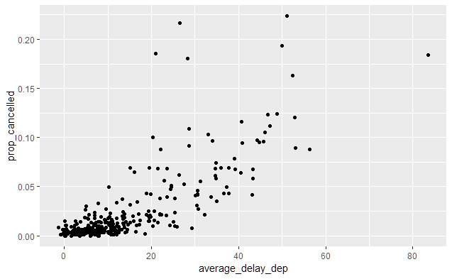

```r
delayprop_avgdelay <- flights %>%
  group_by(year,month,day) %>%
  summarise(cancelled_flight = sum(is.na(dep_time)), prop_cancelled = mean(is.na(dep_time)),
            average_delay_dep = mean(dep_delay, na.rm  = TRUE), average_delay_arr = mean(arr_delay, na.rm = TRUE)) %>%
  filter(prop_cancelled <= 0.3)
ggplot(data = delayprop_avgdelay) + geom_point(mapping = aes(x = average_delay_dep, y = prop_cancelled))
```

##### Prom5. Which carrier has the worst delays? Challenge: can you disentangle the effects of bad airports vs. bad carriers? Why/why not? (Hint: think about flights %>% group_by(carrier, dest) %>% summarise(n()))

```r
flights %>%
  group_by(carrier) %>%
  summarise(delays = mean(arr_delay, na.rm = TRUE)) %>%
  arrange(desc(delays))
```

| carrier | delays |
| --- | --- |
| F9 | 21.9207048 |
| FL | 20.1159055 |
| EV | 15.7964311 |
| YV | 15.5569853 |
| OO | 11.9310345 |
| MQ | 10.7747334 |
| WN | 9.6491199 |
| B6 | 9.4579733 |
| 9E | 7.3796692 |
| UA | 3.5580111 |

[output cut: 6 more lines]

- F9항공사(프런티어 항공)가 가장 큰 arr_delay를 보인다.
- Airport와 Carrier와의 관계를 따로 보기 위해서 다음과 같은 과정을 거치고자 한다.
  1. 우선 carrier와 dest를 group으로 하여 평균 delay와 항공편의 갯수를 센다.
  2. 각 dest 마다 항공사와 무관한 평균적인 delay를 구한다.
  3. 1과 2에서 각각 구한값들을 뺀다. 가령 A공항의 평균적인 지연시간이 10분인데, B항공사는 A공항에서 5분정도의 평균적인 지연시간을 가진다면, 이는 B항공사가 다른 항공사들에 비해 우수한 능력을 가졌음을 의미하므로, dest_adjusted된 A공항의 B항공사 지연시간은 -5분이다. 만약 C항공사는 A공항에서 15정도의 평균 지연시간을 가졌다면, 이는 C항공사가 평균에 비해 5분 정도 더 늦었다는 의미이므로 dest_adjusted된 A공항의 C항공사 지연시간은 5분이다.
  4. 이렇게 구해진 dest_adjusted_delay를 count로 weighted average하여 carrier별로 분류한다.

```r
carrier_dest <- flights %>% group_by(carrier,dest) %>%
  summarise(count = n(),delays = mean(arr_delay, na.rm = TRUE)) %>%
  ungroup() %>%
  group_by(dest) %>%
  mutate(average_dest_delay = weighted.mean(delays, count, na.rm = TRUE))
head(carrier_dest)
```

| carrier | dest | count | delays | average_dest_delay |
| --- | --- | --- | --- | --- |
| 9E | ATL | 59 | 0.8571429 | 11.369693 |
| 9E | AUS | 2 | -3.5000000 | 6.011655 |
| 9E | AVL | 10 | -12.1000000 | 8.044607 |
| 9E | BGR | 1 | NaN | 8.027933 |
| 9E | BNA | 474 | 9.2853982 | 11.873410 |
| 9E | BOS | 914 | 5.6647128 | 2.844598 |

```r
carrier_dest %>%
  mutate(carrier_delay = delays - average_dest_delay) %>%
  ungroup() %>%
  group_by(carrier) %>%
  summarise(dest_adjusted_delay = weighted.mean(carrier_delay,count,na.rm = TRUE)) %>%
  arrange(desc(dest_adjusted_delay))
```

| carrier | dest_adjusted_delay |
| --- | --- |
| F9 | 13.3248388 |
| FL | 6.4725779 |
| YV | 4.8223647 |
| EV | 3.7214606 |
| B6 | 3.2624877 |
| OO | 2.4658924 |
| MQ | 1.5066755 |
| VX | 0.3759251 |
| UA | -0.5118320 |
| WN | -1.0004362 |

[output cut: 6 more lines]

- 앞선 결과아 마찬가지로 F9(프런티어 항공사)가 가장 늦은 delay시간을 가졌다는 것을 알 수 있다. 약간의 차이는 있지만, 자체 delay가 높았던 항공사들이 dest adjusted된 delay 역시 긴 것으로 나타난다.
- 한계점 : arr_delay는 dep_delay와 밀접한 관련이 있는데, 이를 고려하지 않고, dep_delay는 dest마다 일정한 것으로 간주했다. 이는 다소 비현실적인 가정이나, 아래의 그래프에서 대부분의 dep_delay는 비슷한 곳에 집중된다는 점을 간주하면 완전히 자료와 동떨어지지는 않다.

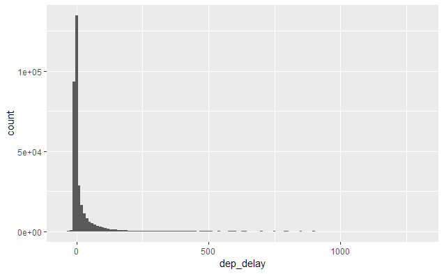

```r
ggplot(data = flights) + geom_histogram(mapping = aes(x = dep_delay),binwidth = 10)
```

##### Prom6. What does `the sort` argument to count() do. When might you use it?

```r
flights %>% count(dest)
```

| dest | n |
| --- | --- |
| ABQ | 254 |
| ACK | 265 |
| ALB | 439 |
| ANC | 8 |
| ATL | 17215 |
| AUS | 2439 |
| AVL | 275 |
| BDL | 443 |
| BGR | 375 |
| BHM | 297 |

[output cut: 95 more lines]

```r
flights %>% count(dest, sort = TRUE)
```

| dest | n |
| --- | --- |
| ORD | 17283 |
| ATL | 17215 |
| LAX | 16174 |
| BOS | 15508 |
| MCO | 14082 |
| CLT | 14064 |
| SFO | 13331 |
| FLL | 12055 |
| MIA | 11728 |
| DCA | 9705 |

[output cut: 95 more lines]

- `sort`를 true로 주면 descending order로 정렬된다.

#### 5.7.1 Exercise

##### Prom1. Refer back to the lists of useful mutate and filtering functions. Describe how each operation changes when you combine it with grouping.

- 각 Function들 중 전체를 필요로 하는 함수들은 그 전체가 group으로 바뀐다. 이때 전체를 필요로 한다는 의미는 mean,median,rank,sum 등 적어도 둘 이상의 자료를 필요로 하는 함수들이다. 그렇지 않은 경우는 차이가 없다.

```r
carrier_group <- flights %>%
  filter(is.na(dep_time) == FALSE) %>%
  group_by(carrier)
not_cancelled <- flights %>%
  filter(is.na(dep_time) == FALSE)
not_cancelled %>%
  mutate(velocity = distance / air_time) %>%
  select(year:day, tailnum, velocity, carrier)
```

| year | month | day | tailnum | velocity | carrier |
| --- | --- | --- | --- | --- | --- |
| 2013 | 1 | 1 | N14228 | 6.167401 | UA |
| 2013 | 1 | 1 | N24211 | 6.237885 | UA |
| 2013 | 1 | 1 | N619AA | 6.806250 | AA |
| 2013 | 1 | 1 | N804JB | 8.612022 | B6 |
| 2013 | 1 | 1 | N668DN | 6.568966 | DL |
| 2013 | 1 | 1 | N39463 | 4.793333 | UA |
| 2013 | 1 | 1 | N516JB | 6.740506 | B6 |
| 2013 | 1 | 1 | N829AS | 4.320755 | EV |
| 2013 | 1 | 1 | N593JB | 6.742857 | B6 |
| 2013 | 1 | 1 | N3ALAA | 5.311594 | AA |

[output cut: 990 more lines]

```r
carrier_group %>%
  mutate(velocity = distance / air_time) %>%
  select(year:day, tailnum, velocity, carrier)
```

| year | month | day | tailnum | velocity | carrier |
| --- | --- | --- | --- | --- | --- |
| 2013 | 1 | 1 | N14228 | 6.167401 | UA |
| 2013 | 1 | 1 | N24211 | 6.237885 | UA |
| 2013 | 1 | 1 | N619AA | 6.806250 | AA |
| 2013 | 1 | 1 | N804JB | 8.612022 | B6 |
| 2013 | 1 | 1 | N668DN | 6.568966 | DL |
| 2013 | 1 | 1 | N39463 | 4.793333 | UA |
| 2013 | 1 | 1 | N516JB | 6.740506 | B6 |
| 2013 | 1 | 1 | N829AS | 4.320755 | EV |
| 2013 | 1 | 1 | N593JB | 6.742857 | B6 |
| 2013 | 1 | 1 | N3ALAA | 5.311594 | AA |

[output cut: 990 more lines]

- 위 두 표는 차이가 없음을 알 수 있다.

```r
not_cancelled %>%
  mutate(mean_distance = mean(distance)) %>%
  select(carrier, mean_distance)
```

| carrier | mean_distance |
| --- | --- |
| UA | 1048.571 |
| UA | 1048.571 |
| AA | 1048.571 |
| B6 | 1048.571 |
| DL | 1048.571 |
| UA | 1048.571 |
| B6 | 1048.571 |
| EV | 1048.571 |
| B6 | 1048.571 |
| AA | 1048.571 |

[output cut: 990 more lines]

```r
carrier_group %>%
  mutate(mean_distance = mean(distance)) %>%
  select(carrier, mean_distance)
```

| carrier | mean_distance |
| --- | --- |
| UA | 1532.0732 |
| UA | 1532.0732 |
| AA | 1343.1190 |
| B6 | 1070.3886 |
| DL | 1238.1456 |
| UA | 1532.0732 |
| B6 | 1070.3886 |
| EV | 563.5075 |
| B6 | 1070.3886 |
| AA | 1343.1190 |

[output cut: 990 more lines]

- mean의 경우 첫 표는 전체의 mean이 나온 반면 두번째 표는 carrier별 mean이 나온것을 알 수 있다.

```r
not_cancelled %>%
  mutate(r = min_rank(distance)) %>%
  select(year:day, tailnum, carrier, r) %>%
  filter(carrier == "UA") %>%
  arrange(r)
```

| year | month | day | tailnum | carrier | r |
| --- | --- | --- | --- | --- | --- |
| 2013 | 12 | 10 | N846UA | UA | 1550 |
| 2013 | 12 | 11 | N852UA | UA | 1550 |
| 2013 | 12 | 12 | N851UA | UA | 1550 |
| 2013 | 12 | 13 | N814UA | UA | 1550 |
| 2013 | 12 | 15 | N811UA | UA | 1550 |
| 2013 | 12 | 16 | N819UA | UA | 1550 |
| 2013 | 12 | 17 | N839UA | UA | 1550 |
| 2013 | 12 | 12 | N834UA | UA | 14971 |
| 2013 | 12 | 15 | N817UA | UA | 14971 |
| 2013 | 1 | 1 | N534UA | UA | 16815 |

[output cut: 990 more lines]

```r
carrier_group %>%
  mutate(r = min_rank(distance)) %>%
  select(year:day, tailnum, carrier, r)%>%
  filter(carrier == "UA") %>%
  arrange(r)
```

| year | month | day | tailnum | carrier | r |
| --- | --- | --- | --- | --- | --- |
| 2013 | 12 | 10 | N846UA | UA | 1 |
| 2013 | 12 | 11 | N852UA | UA | 1 |
| 2013 | 12 | 12 | N851UA | UA | 1 |
| 2013 | 12 | 13 | N814UA | UA | 1 |
| 2013 | 12 | 15 | N811UA | UA | 1 |
| 2013 | 12 | 16 | N819UA | UA | 1 |
| 2013 | 12 | 17 | N839UA | UA | 1 |
| 2013 | 12 | 12 | N834UA | UA | 8 |
| 2013 | 12 | 15 | N817UA | UA | 8 |
| 2013 | 1 | 1 | N534UA | UA | 10 |

[output cut: 990 more lines]

- rank 역시 같은 항공편이라도 다른 rank가 주어지는 것을 알 수 있다. group을 할 경우 group내에서만 등수가 정해진다.

##### Prom2. Which plane (tailnum) has the worst on-time record?

```r
# delay proportion
flights %>%
  filter(!(is.na(dep_time))) %>%
  group_by(tailnum) %>%
  summarise(prop_delay = mean(arr_delay > 0)) %>%
  arrange(desc(prop_delay))
```

| tailnum | prop_delay |
| --- | --- |
| N121DE | 1.0000000 |
| N136DL | 1.0000000 |
| N143DA | 1.0000000 |
| N17627 | 1.0000000 |
| N240AT | 1.0000000 |
| N26906 | 1.0000000 |
| N295AT | 1.0000000 |
| N302AS | 1.0000000 |
| N303AS | 1.0000000 |
| N32626 | 1.0000000 |

[output cut: 990 more lines]

```r
# on time proportion
flights %>%
  filter(!(is.na(dep_time))) %>%
  group_by(tailnum) %>%
  summarise(prop_ontime = mean(arr_delay == 0)) %>%
  arrange(desc(prop_ontime))
```

| tailnum | prop_ontime |
| --- | --- |
| N7BVAA | 1.00000000 |
| N956DN | 1.00000000 |
| N1611B | 0.50000000 |
| N613SW | 0.50000000 |
| N670SW | 0.50000000 |
| N658UA | 0.33333333 |
| N590AS | 0.25000000 |
| N368SW | 0.20000000 |
| N449US | 0.20000000 |
| N541US | 0.20000000 |

[output cut: 990 more lines]

```r
NA
```

##### Prom3. What time of day should you fly if you want to avoid delays as much as possible?

- delay를 최대한 피해야 하는데, dep_delay와 arr_delay의 경우 모두 찾아보도록 한다. 우선 아래의 그래프는 dep_time을 자정으로부터 몇분이 지났는지로 바꾼후, delay proportion을 계산한 이후 그래프를 그린 것이다. 시간을 수정한 이유는 원래 데이터를 그대로 사용할 경우 col사이에 빈칸이 생기기 때문이다.
- 아래에서 확인할 수 있듯, dep_delay를 피하기 위해서는 새벽 4시에서 5시 사이의 비행기를 타는 것이 가장 좋다고 할 수 있다.

```r
prop_delay <- flights %>%
  filter(!is.na(dep_time)) %>%
  mutate(dep_time_min = (dep_time %/% 100)*60 + (dep_time %% 100)) %>%
  group_by(dep_time_min) %>%
  summarise(prop_delay = mean(dep_delay >0, na.rm = TRUE)) %>%
  arrange(prop_delay)
prop_delay
```

| dep_time_min | prop_delay |
| --- | --- |
| 285 | 0.000000000 |
| 286 | 0.000000000 |
| 287 | 0.000000000 |
| 288 | 0.000000000 |
| 289 | 0.000000000 |
| 290 | 0.000000000 |
| 291 | 0.000000000 |
| 292 | 0.000000000 |
| 293 | 0.000000000 |
| 294 | 0.000000000 |

[output cut: 990 more lines]

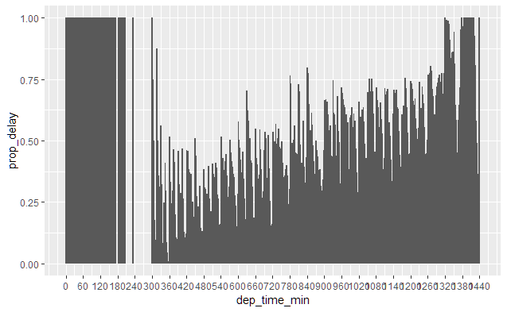

```r
ggplot(data = prop_delay) +
  geom_col(mapping = aes(x = dep_time_min, y = prop_delay),width = 5) +
  scale_x_continuous(breaks = seq(0, 1440,by = 60))
```

- 이제 arr_delay를 피하기 위한 deptime을 알아보면 이 역시 마찬가지로 새벽 4시와 5시 사이의 비행기가 가장 지연율이 낮은 것을 확인할 수 있다. 따라서 새벽 4시에서 5시 사이의 비행기를 타는 것이 적절하다.

```r
prop_delay2 <- flights %>%
  filter(!is.na(dep_time)) %>%
  mutate(dep_time_min = (dep_time %/% 100)*60 + (dep_time %% 100)) %>%
  group_by(dep_time_min) %>%
  summarise(prop_delay2 = mean(arr_delay >0, na.rm = TRUE))
prop_delay2
```

| dep_time_min | prop_delay2 |
| --- | --- |
| 1 | 0.72000000 |
| 2 | 0.65714286 |
| 3 | 0.73076923 |
| 4 | 0.84615385 |
| 5 | 0.90000000 |
| 6 | 0.81818182 |
| 7 | 0.77272727 |
| 8 | 0.86956522 |
| 9 | 0.82142857 |
| 10 | 0.95454545 |

[output cut: 990 more lines]

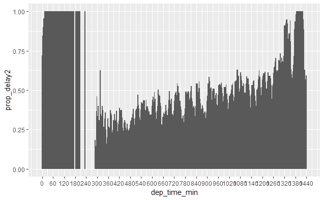

```r
ggplot(data = prop_delay2) +
  geom_col(mapping = aes(x = dep_time_min, y = prop_delay2),width = 5) +
  scale_x_continuous(breaks = seq(0, 1440,by = 60))
```

##### Prom4. For each destination, compute the total minutes of delay. For each flight, compute the proportion of the total delay for its destination.

| dest | flight | total_delay | tot_delay_dest | prop_of_flight |
| --- | --- | --- | --- | --- |
| IAH | 1545 | -810 | 30046 | -2.695866e-02 |
| IAH | 1714 | -377 | 30046 | -1.254743e-02 |
| MIA | 1141 | -584 | 3467 | -1.684453e-01 |
| BQN | 725 | 196 | 7322 | 2.676864e-02 |
| ATL | 461 | -1517 | 190260 | -7.973300e-03 |
| ORD | 1696 | 12 | 97352 | 1.232640e-04 |
| FLL | 507 | 157 | 96153 | 1.632814e-03 |
| IAD | 5708 | 115 | 74631 | 1.540915e-03 |
| MCO | 79 | -374 | 76185 | -4.909103e-03 |
| ORD | 301 | -3121 | 97352 | -3.205892e-02 |

[output cut: 990 more lines]

##### Prom5. Delays are typically temporally correlated: even once the problem that caused the initial delay has been resolved, later flights are delayed to allow earlier flights to leave. Using lag(), explore how the delay of a flight is related to the delay of the immediately preceding flight.

```r
Previous_delay <- flights %>%
  mutate(previous_delay = lag(dep_delay)) %>%
  select(dep_delay, previous_delay, everything()) %>%
  mutate(gap_dep_pre = dep_delay - previous_delay)
Previous_delay
```

| dep_delay | previous_delay | year | month | day | dep_time | sched_dep_time | arr_time | sched_arr_time | arr_delay | carrier | flight | tailnum | origin | dest | air_time | distance | hour | minute | time_hour | gap_dep_pre |
| --- | --- | --- | --- | --- | --- | --- | --- | --- | --- | --- | --- | --- | --- | --- | --- | --- | --- | --- | --- | --- |
| 2 | NA | 2013 | 1 | 1 | 517 | 515 | 830 | 819 | 11 | UA | 1545 | N14228 | EWR | IAH | 227 | 1400 | 5 | 15 | 2013-01-01 05:00:00 | NA |
| 4 | 2 | 2013 | 1 | 1 | 533 | 529 | 850 | 830 | 20 | UA | 1714 | N24211 | LGA | IAH | 227 | 1416 | 5 | 29 | 2013-01-01 05:00:00 | 2 |
| 2 | 4 | 2013 | 1 | 1 | 542 | 540 | 923 | 850 | 33 | AA | 1141 | N619AA | JFK | MIA | 160 | 1089 | 5 | 40 | 2013-01-01 05:00:00 | -2 |
| -1 | 2 | 2013 | 1 | 1 | 544 | 545 | 1004 | 1022 | -18 | B6 | 725 | N804JB | JFK | BQN | 183 | 1576 | 5 | 45 | 2013-01-01 05:00:00 | -3 |
| -6 | -1 | 2013 | 1 | 1 | 554 | 600 | 812 | 837 | -25 | DL | 461 | N668DN | LGA | ATL | 116 | 762 | 6 | 0 | 2013-01-01 06:00:00 | -5 |
| -4 | -6 | 2013 | 1 | 1 | 554 | 558 | 740 | 728 | 12 | UA | 1696 | N39463 | EWR | ORD | 150 | 719 | 5 | 58 | 2013-01-01 05:00:00 | 2 |
| -5 | -4 | 2013 | 1 | 1 | 555 | 600 | 913 | 854 | 19 | B6 | 507 | N516JB | EWR | FLL | 158 | 1065 | 6 | 0 | 2013-01-01 06:00:00 | -1 |
| -3 | -5 | 2013 | 1 | 1 | 557 | 600 | 709 | 723 | -14 | EV | 5708 | N829AS | LGA | IAD | 53 | 229 | 6 | 0 | 2013-01-01 06:00:00 | 2 |
| -3 | -3 | 2013 | 1 | 1 | 557 | 600 | 838 | 846 | -8 | B6 | 79 | N593JB | JFK | MCO | 140 | 944 | 6 | 0 | 2013-01-01 06:00:00 | 0 |
| -2 | -3 | 2013 | 1 | 1 | 558 | 600 | 753 | 745 | 8 | AA | 301 | N3ALAA | LGA | ORD | 138 | 733 | 6 | 0 | 2013-01-01 06:00:00 | 1 |

[output cut: 990 more lines]

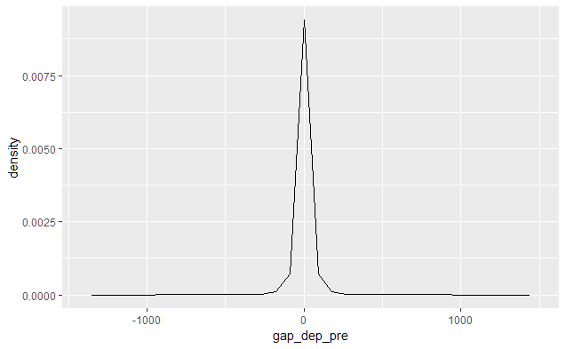

```r
ggplot(data = Previous_delay) + geom_freqpoly(mapping = aes(x = gap_dep_pre, y = ..density..))
```

- 위의 table을 보면 이전의 delay가 그 다음 비행기의 delay에 영향을 준다는 것을 확인할 수 있으며, 이를 시각화 하기 위해서 둘의 차이를 그래프로 그려보면 거의 대부분의 값들이 0근처에 모여있음을 즉, 둘 사이의 차이가 거의 아주 가깝다는 것을 확인할 있 있다.

##### Prom6. Look at each destination. Can you find flights that are suspiciously fast? (i.e. flights that represent a potential data entry error). Compute the air time a flight relative to the shortest flight to that destination. Which flights were most delayed in the air?

| velocity | year | month | day | dep_time | sched_dep_time | dep_delay | arr_time | sched_arr_time | arr_delay | carrier | flight | tailnum | origin | dest | air_time | distance | hour | minute | time_hour |
| --- | --- | --- | --- | --- | --- | --- | --- | --- | --- | --- | --- | --- | --- | --- | --- | --- | --- | --- | --- |
| 11.723077 | 2013 | 5 | 25 | 1709 | 1700 | 9 | 1923 | 1937 | -14 | DL | 1499 | N666DN | LGA | ATL | 65 | 762 | 17 | 0 | 2013-05-25 17:00:00 |
| 10.838710 | 2013 | 7 | 2 | 1558 | 1513 | 45 | 1745 | 1719 | 26 | EV | 4667 | N17196 | EWR | MSP | 93 | 1008 | 15 | 13 | 2013-07-02 15:00:00 |
| 10.800000 | 2013 | 5 | 13 | 2040 | 2025 | 15 | 2225 | 2226 | -1 | EV | 4292 | N14568 | EWR | GSP | 55 | 594 | 20 | 25 | 2013-05-13 20:00:00 |
| 10.685714 | 2013 | 3 | 23 | 1914 | 1910 | 4 | 2045 | 2043 | 2 | EV | 3805 | N12567 | EWR | BNA | 70 | 748 | 19 | 10 | 2013-03-23 19:00:00 |
| 9.857143 | 2013 | 1 | 12 | 1559 | 1600 | -1 | 1849 | 1917 | -28 | DL | 1902 | N956DL | LGA | PBI | 105 | 1035 | 16 | 0 | 2013-01-12 16:00:00 |
| 9.400000 | 2013 | 11 | 17 | 650 | 655 | -5 | 1059 | 1150 | -51 | DL | 315 | N3768 | JFK | SJU | 170 | 1598 | 6 | 55 | 2013-11-17 06:00:00 |
| 9.290698 | 2013 | 2 | 21 | 2355 | 2358 | -3 | 412 | 438 | -26 | B6 | 707 | N779JB | JFK | SJU | 172 | 1598 | 23 | 58 | 2013-02-21 23:00:00 |
| 9.274286 | 2013 | 11 | 17 | 759 | 800 | -1 | 1212 | 1255 | -43 | AA | 936 | N5FFAA | JFK | STT | 175 | 1623 | 8 | 0 | 2013-11-17 08:00:00 |
| 9.236994 | 2013 | 11 | 16 | 2003 | 1925 | 38 | 17 | 36 | -19 | DL | 347 | N3773D | JFK | SJU | 173 | 1598 | 19 | 25 | 2013-11-16 19:00:00 |
| 9.236994 | 2013 | 11 | 16 | 2349 | 2359 | -10 | 402 | 440 | -38 | B6 | 1503 | N571JB | JFK | SJU | 173 | 1598 | 23 | 59 | 2013-11-16 23:00:00 |

[output cut: 990 more lines]

##### Prom7. Find all destinations that are flown by at least two carriers. Use that information to rank the carriers.

```r
flights %>% group_by(dest) %>%
  summarise(number_carrier = n_distinct(carrier)) %>%
  filter(number_carrier >=2)
```

| dest | number_carrier |
| --- | --- |
| ATL | 7 |
| AUS | 6 |
| AVL | 2 |
| BDL | 2 |
| BGR | 2 |
| BNA | 5 |
| BOS | 7 |
| BQN | 2 |
| BTV | 3 |
| BUF | 4 |

[output cut: 66 more lines]

- 위 목록에 있는 destination들이 적어도 2개 이상의 항공사를 가지는 destination들이다.
- carrier 들을 rank 하라는 의미가 불분명하나, 얼마나 많은 dest를 가지느냐로 받아들인다면

| carrier | number_dest | r |
| --- | --- | --- |
| EV | 61 | 1 |
| 9E | 49 | 2 |
| UA | 47 | 3 |
| B6 | 42 | 4 |
| DL | 40 | 5 |
| MQ | 20 | 6 |
| AA | 19 | 7 |
| WN | 11 | 8 |
| US | 6 | 9 |
| OO | 5 | 10 |

[output cut: 6 more lines]

-EV 항공사(익스프레스 제트)가 가장 많은 dest를 가진다.

##### Prom8. For each plane, count the number of flights before the first delay of greater than 1 hour.